# NYC Yellow Taxi Fleet Positioning System

## Group 10 - BUDT 758J: Enterprise Cloud Computing and Big Data

### Robert H. Smith School of Business | Spring 2026

## Business Context

**Decision Maker:** A NYC Yellow Taxi fleet manager responsible for repositioning idle cabs across the city's 263 taxi zones in real time.

**Core Question:** Given the current time of day, weather conditions, scheduled public events, and neighbourhood complaint patterns - *which zones need more cabs right now, and which need fewer?*

Fleet managers don't just need a demand forecast instead they need **directional, actionable guidance**: move cabs from Zone A to Zone B when it rains; pre-position near Zone C an hour before a large event ends. Our analysis is built around that decision, not just prediction accuracy.

## Data Sources

| # | Dataset | Source | Key Variables |
| --- | --- | --- | --- |
| 1 | NYC Yellow Taxi Trip Records (2025) | NYC TLC | Pickup zone, timestamp to hourly demand counts |
| 2 | Hourly Weather (2025) | Open-Meteo Archive API | Temperature, precipitation, weather code |
| 3 | NYC Taxi Zone Shapefiles | NYC TLC | Zone boundaries (263 polygons), borough names |
| 4 | Special Events Permits (2025) | NYC Open Data | Event name, type, borough, scheduled dates |
| 5 | 311 Service Complaints (2025) | NYC Open Data | Complaint type, descriptor text, coordinates |

## Analytical Approach

1. **Data Acquisition**: Five public data sources pulled via REST APIs and cloud file storage
2. **Text Analysis**: Classify event permits by type using tokenization and TF-IDF
3. **Sentiment Analysis**: Score 311 complaint severity from free-text descriptions using VADER
4. **Geocoding**: Map complaint and event locations to taxi zones using spatial joins
5. **Exploratory Analysis**: Understand demand patterns across time, weather, events, and complaints
6. **Demand Modelling**: Quantify how much each external data source improves predictions
7. **Repositioning Scores**: Translate findings into actionable zone-level guidance
8. **AI-Powered Synthesis**: Use a large language model to generate natural language recommendations

## Part 0 - Environment Setup

We install two additional packages and import everything needed for the project. All data acquisition, text processing, geographic analysis, machine learning, and AI components are loaded here so the notebook can run cleanly from top to bottom.

```python
!pip install vaderSentiment groq --quiet
print('Packages installed.')
```

```
   ━━━━━━━━━━━━━━━━━━━━━━━━━━━━━━━━━━━━━━━━ 126.0/126.0 kB 3.5 MB/s eta 0:00:00
   ━━━━━━━━━━━━━━━━━━━━━━━━━━━━━━━━━━━━━━━━ 142.3/142.3 kB 5.6 MB/s eta 0:00:00
Packages installed.
```

```python
import os, re, zipfile, warnings, requests
import numpy as np
import pandas as pd
import matplotlib.pyplot as plt
import geopandas as gpd
from collections import Counter
from sklearn.feature_extraction.text import TfidfVectorizer
from vaderSentiment.vaderSentiment import SentimentIntensityAnalyzer
import nltk
nltk.download('punkt_tab', quiet=True)
tokenizer = nltk.data.load('tokenizers/punkt/PY3/english.pickle')

warnings.filterwarnings('ignore')
plt.rcParams['figure.dpi'] = 120
print('All libraries loaded.')
```

```
All libraries loaded.
```

### Connecting to Cloud Storage

```python
from google.colab import drive
drive.mount('/content/drive')

BASE_PATH = '/content/drive/MyDrive/CloudComputingProject'
parquet_files = [f for f in os.listdir(BASE_PATH) if f.endswith('.parquet')]
print(f'Parquet files found: {len(parquet_files)}')
print(os.listdir(BASE_PATH))
```

```
Parquet files found: 15
['yellow_tripdata_2025-01.parquet', 'yellow_tripdata_2025-02.parquet', 'yellow_tripdata_2025-03.parquet', 'yellow_tripdata_2025-04.parquet', 'yellow_tripdata_2025-05.parquet', 'yellow_tripdata_2025-06.parquet', 'yellow_tripdata_2025-07.parquet', 'yellow_tripdata_2025-08.parquet', 'yellow_tripdata_20…
```

## Part 1 - Data Acquisition

Acquiring clean, reliable data from multiple sources is the foundation of this project. We pull from five distinct sources and validate each one before moving to the next step.

### 1.1 NYC Yellow Taxi Trip Records

The NYC Taxi & Limousine Commission publishes one parquet file per month containing every yellow cab trip. Each row is a single trip with a pickup datetime and a pickup zone ID (one of 263 zones).

**Our aggregation logic:**

- Filter each file to records within the correct calendar month, removing misdated rows that appear occasionally in the raw data
- Floor pickup timestamps to the hour; a fleet manager acts at the hourly level, not the individual trip level
- Count trips per zone per hour becomes our `demand` variable

We define a reusable function first and test it on a single file before running the full loop across all 12 months.

```python
# Define a function to process one monthly file.
def process_taxi_file(file_path):
    df = pd.read_parquet(file_path)
    df['tpep_pickup_datetime'] = pd.to_datetime(df['tpep_pickup_datetime'], errors='coerce')
    df = df.dropna(subset=['tpep_pickup_datetime'])

    # Extract expected month from filename and filter to it
    parts = os.path.basename(file_path).replace('.parquet','').split('_')[-1].split('-')
    year, month = parts[0], parts[1]
    start = f'{year}-{month}-01'
    end   = pd.to_datetime(start) + pd.DateOffset(months=1)
    df    = df[(df['tpep_pickup_datetime'] >= start) & (df['tpep_pickup_datetime'] < end)]

    df['pickup_hour'] = df['tpep_pickup_datetime'].dt.floor('h')
    return df.groupby(['pickup_hour','PULocationID']).size().reset_index(name='demand')

# Test on January before running the full loop
sample = process_taxi_file(os.path.join(BASE_PATH, 'yellow_tripdata_2025-01.parquet'))
print(f'January test: {len(sample):,} zone-hour records')
sample
```

```
January test: 97,014 zone-hour records
```

|  | pickup_hour | PULocationID | demand |
| --- | --- | --- | --- |
| 0 | 2025-01-01 00:00:00 | 4 | 28 |
| 1 | 2025-01-01 00:00:00 | 7 | 12 |
| 2 | 2025-01-01 00:00:00 | 9 | 1 |
| 3 | 2025-01-01 00:00:00 | 10 | 1 |
| 4 | 2025-01-01 00:00:00 | 12 | 1 |
| ... | ... | ... | ... |
| 97009 | 2025-01-31 23:00:00 | 261 | 35 |
| 97010 | 2025-01-31 23:00:00 | 262 | 29 |
| 97011 | 2025-01-31 23:00:00 | 263 | 133 |
| 97012 | 2025-01-31 23:00:00 | 264 | 20 |
| 97013 | 2025-01-31 23:00:00 | 265 | 1 |

97014 rows × 3 columns

```python
taxi_files = sorted([f for f in os.listdir(BASE_PATH)
                     if f.startswith('yellow_tripdata_2025') and f.endswith('.parquet')])

all_months = []
for fname in taxi_files:
    print(f'  Processing {fname}...')
    all_months.append(process_taxi_file(os.path.join(BASE_PATH, fname)))

full_data = pd.concat(all_months, ignore_index=True)
full_data = full_data.rename(columns={'PULocationID': 'LocationID'})
full_data['date']        = full_data['pickup_hour'].dt.date
full_data['hour']        = full_data['pickup_hour'].dt.hour
full_data['day_of_week'] = full_data['pickup_hour'].dt.day_name()

print(f'\nTotal zone-hour records: {len(full_data):,}')
print(f'Date range: {full_data["pickup_hour"].min()} → {full_data["pickup_hour"].max()}')
```

```
  Processing yellow_tripdata_2025-01.parquet...
  Processing yellow_tripdata_2025-02.parquet...
  Processing yellow_tripdata_2025-03.parquet...
  Processing yellow_tripdata_2025-04.parquet...
  Processing yellow_tripdata_2025-05.parquet...
  Processing yellow_tripdata_2025-06.parquet...
  Processing yellow_tripdata_2025-07.parquet...
  Processing yellow_tripdata_2025-08.parquet...
  Processing yellow_tripdata_2025-09.parquet...
  Processing yellow_tripdata_2025-10.parquet...
  Processing yellow_tripdata_2025-11.parquet...
  Processing yellow_tripdata_2025-12.parquet...

Total zone-hour records: 1,430,274
Date range: 2025-01-01 00:00:00 → 2025-12-31 23:00:00
```

```python
print('=== Taxi Data Validation ===')
print(f'Unique zones: {full_data["LocationID"].nunique()} (expect up to 263)')
print(f'Unique dates: {full_data["date"].nunique()}')
print(f'\nDemand summary:')
print(full_data['demand'].describe().round(1).to_string())
full_data
```

```
=== Taxi Data Validation ===
Unique zones: 262 (expect up to 263)
Unique dates: 365

Demand summary:
count    1430274.0
mean          34.1
std           73.3
min            1.0
25%            2.0
50%            4.0
75%           22.0
max         1300.0
```

|  | pickup_hour | LocationID | demand | date | hour | day_of_week |
| --- | --- | --- | --- | --- | --- | --- |
| 0 | 2025-01-01 00:00:00 | 4 | 28 | 2025-01-01 | 0 | Wednesday |
| 1 | 2025-01-01 00:00:00 | 7 | 12 | 2025-01-01 | 0 | Wednesday |
| 2 | 2025-01-01 00:00:00 | 9 | 1 | 2025-01-01 | 0 | Wednesday |
| 3 | 2025-01-01 00:00:00 | 10 | 1 | 2025-01-01 | 0 | Wednesday |
| 4 | 2025-01-01 00:00:00 | 12 | 1 | 2025-01-01 | 0 | Wednesday |
| ... | ... | ... | ... | ... | ... | ... |
| 1430269 | 2025-12-31 23:00:00 | 261 | 24 | 2025-12-31 | 23 | Wednesday |
| 1430270 | 2025-12-31 23:00:00 | 262 | 69 | 2025-12-31 | 23 | Wednesday |
| 1430271 | 2025-12-31 23:00:00 | 263 | 154 | 2025-12-31 | 23 | Wednesday |
| 1430272 | 2025-12-31 23:00:00 | 264 | 6 | 2025-12-31 | 23 | Wednesday |
| 1430273 | 2025-12-31 23:00:00 | 265 | 5 | 2025-12-31 | 23 | Wednesday |

1430274 rows × 6 columns

### 1.2 Weather Data - Open-Meteo REST API

Weather is one of the strongest external drivers of taxi demand. We retrieve hourly observations for all of 2025 from the Open-Meteo Historical Archive using a REST API call. Variables retrieved: temperature (°C), precipitation (mm), and WMO weather interpretation code.

```python
def fetch_nyc_weather(start_date='2025-01-01', end_date='2025-12-31'):
    url    = 'https://archive-api.open-meteo.com/v1/archive'
    params = {
        'latitude': 40.7128, 'longitude': -74.0060,
        'start_date': start_date, 'end_date': end_date,
        'hourly': ['temperature_2m','precipitation','weather_code'],
        'timezone': 'America/New_York'
    }
    print('Calling Open-Meteo API...')
    r = requests.get(url, params=params)
    r.raise_for_status()
    hourly = r.json()['hourly']
    return pd.DataFrame({
        'pickup_hour':  pd.to_datetime(hourly['time']).floor('h'),
        'temp_c':       hourly['temperature_2m'],
        'precip_mm':    hourly['precipitation'],
        'weather_code': hourly['weather_code']
    })

weather_2025 = fetch_nyc_weather()
print(f'Records: {len(weather_2025):,} (expect 8,760 for full year)')
weather_2025
```

```
Calling Open-Meteo API...
Records: 8,760 (expect 8,760 for full year)
```

|  | pickup_hour | temp_c | precip_mm | weather_code |
| --- | --- | --- | --- | --- |
| 0 | 2025-01-01 00:00:00 | 8.1 | 3.4 | 63 |
| 1 | 2025-01-01 01:00:00 | 9.1 | 0.9 | 53 |
| 2 | 2025-01-01 02:00:00 | 8.6 | 0.0 | 3 |
| 3 | 2025-01-01 03:00:00 | 8.9 | 0.0 | 3 |
| 4 | 2025-01-01 04:00:00 | 8.8 | 0.0 | 3 |
| ... | ... | ... | ... | ... |
| 8755 | 2025-12-31 19:00:00 | -2.5 | 0.0 | 3 |
| 8756 | 2025-12-31 20:00:00 | -2.5 | 0.0 | 2 |
| 8757 | 2025-12-31 21:00:00 | -2.5 | 0.0 | 3 |
| 8758 | 2025-12-31 22:00:00 | -2.0 | 0.0 | 3 |
| 8759 | 2025-12-31 23:00:00 | -1.5 | 0.0 | 3 |

8760 rows × 4 columns

```python
# Validate the weather data.
print('=== Weather Validation ===')
print(f'Missing values: {weather_2025.isna().sum().to_dict()}')
print(f'Temperature range: {weather_2025["temp_c"].min():.1f}°C to {weather_2025["temp_c"].max():.1f}°C')
print(f'Rainy hours (precip > 0): {(weather_2025["precip_mm"] > 0).sum():,}')
```

```
=== Weather Validation ===
Missing values: {'pickup_hour': 0, 'temp_c': 0, 'precip_mm': 0, 'weather_code': 0}
Temperature range: -16.6°C to 40.4°C
Rainy hours (precip > 0): 1,209
```

**Weather data is complete and clean.** All 8,760 hourly records are present with no missing values. The temperature range of -16.6°C to 40.4°C reflects a full NYC year where both extremes are relevant, as very cold and very hot conditions both suppress walking and push riders toward cabs. Rain fell in 1,209 of 8,760 hours (roughly 14% of the year), giving us a meaningful rainy-hour sample for the demand comparisons in Part 5.

### 1.3 NYC Taxi Zone Shapefiles

The NYC TLC distributes a shapefile defining the exact polygon boundary of each of the 263 taxi zones. We load this using `geopandas` and reproject to WGS84 (EPSG:4326) so that coordinate systems are consistent with our other datasets.

This shapefile serves two purposes: it lets us attach zone names and borough labels to our demand data, and it is the reference geometry we use to geocode complaint and event locations in Part 3.

```python
# Extract and load the shapefile.
zip_path     = os.path.join(BASE_PATH, 'taxi_zones(1).zip')
extract_path = os.path.join(BASE_PATH, 'taxi_zones')

if not os.path.exists(extract_path):
    with zipfile.ZipFile(zip_path, 'r') as z:
        z.extractall(extract_path)

zones = gpd.read_file(os.path.join(extract_path, 'taxi_zones', 'taxi_zones.shp'))
zones = zones[['LocationID','zone','borough','geometry']].to_crs(epsg=4326)

print(f'Zones loaded: {len(zones)} (expect 263)')
print(zones['borough'].value_counts().to_string())
zones
```

```
Zones loaded: 263 (expect 263)
borough
Queens           69
Manhattan        69
Brooklyn         61
Bronx            43
Staten Island    20
EWR               1
```

|  | LocationID | zone | borough | geometry |
| --- | --- | --- | --- | --- |
| 0 | 1 | Newark Airport | EWR | POLYGON ((-74.18445 40.695, -74.18449 40.6951,... |
| 1 | 2 | Jamaica Bay | Queens | MULTIPOLYGON (((-73.82338 40.63899, -73.82277 ... |
| 2 | 3 | Allerton/Pelham Gardens | Bronx | POLYGON ((-73.84793 40.87134, -73.84725 40.870... |
| 3 | 4 | Alphabet City | Manhattan | POLYGON ((-73.97177 40.72582, -73.97179 40.725... |
| 4 | 5 | Arden Heights | Staten Island | POLYGON ((-74.17422 40.56257, -74.17349 40.562... |
| ... | ... | ... | ... | ... |
| 258 | 259 | Woodlawn/Wakefield | Bronx | POLYGON ((-73.85107 40.91037, -73.85207 40.909... |
| 259 | 260 | Woodside | Queens | POLYGON ((-73.90175 40.76078, -73.90147 40.759... |
| 260 | 261 | World Trade Center | Manhattan | POLYGON ((-74.01333 40.70503, -74.01327 40.704... |
| 261 | 262 | Yorkville East | Manhattan | MULTIPOLYGON (((-73.94383 40.78286, -73.94376 ... |
| 262 | 263 | Yorkville West | Manhattan | POLYGON ((-73.95219 40.77302, -73.95269 40.772... |

263 rows × 4 columns

**Shapefile loaded correctly.** All 263 zones are present. One zone: EWR (Newark Airport) is technically in New Jersey, but yellow cabs are permitted to pick up there and it is included in the standard TLC zone system. It accounts for very low trip volume and does not affect the analysis. The mix of POLYGON and MULTIPOLYGON geometry types is expected for zones that span water bodies or disconnected land areas.

### 1.4 NYC Special Events Permits

The NYC Open Data portal publishes all city-issued special event permits via a publicly accessible REST API. Each permit describes an event that required a formal city permit these include: street fairs, parades, marathons, film shoots, concerts, and more.

Key fields: event name and type (free text), the issuing borough, and scheduled start and end times. **Note:** This dataset does not include latitude/longitude coordinates for all records - we address the geographic assignment in Part 3 using the borough field.

We pull broadly (no date filter in the API query, which can cause silent failures) and filter to 2025 records in pandas.

```python
# We fetch broadly and filter to 2025 in pandas — safer than SoQL date quoting.
def fetch_nyc_events(limit=50000):
    url    = 'https://data.cityofnewyork.us/resource/bkfu-528j.json'
    params = {'$limit': limit, '$order': 'start_date_time DESC'}
    print('Calling NYC Open Data events API...')
    r = requests.get(url, params=params)
    r.raise_for_status()
    df = pd.DataFrame(r.json())
    print(f'Total pulled: {len(df):,}')
    return df

events_raw_full = fetch_nyc_events()
print('Columns:', list(events_raw_full.columns))
```

```
Calling NYC Open Data events API...
Total pulled: 50,000
Columns: ['event_agency', 'event_id', 'event_name', 'start_date_time', 'end_date_time', 'event_type', 'event_borough', 'event_location', 'street_closure_type', 'community_board', 'police_precinct', 'event_street_side']
```

```python
# Parse dates, filter to 2025, cast numeric fields.
events_raw_full['start_date_time'] = pd.to_datetime(events_raw_full['start_date_time'], errors='coerce')
events_raw_full = events_raw_full.dropna(subset=['start_date_time'])

events_raw = events_raw_full[events_raw_full['start_date_time'].dt.year == 2025].copy()
print(f'2025 events: {len(events_raw):,}')

for col in ['latitude','longitude','attendance']:
    events_raw[col] = pd.to_numeric(events_raw.get(col, np.nan), errors='coerce')

events_raw['event_hour'] = events_raw['start_date_time'].dt.floor('h')
for col in ['event_name','event_type']:
    if col in events_raw.columns:
        events_raw[col] = events_raw[col].fillna('').str.lower().str.strip()

print(f'Events with lat/lon: {events_raw["latitude"].notna().sum():,}')
print('By borough:'); print(events_raw['event_borough'].value_counts().to_string())
```

```
2025 events: 31,182
Events with lat/lon: 0
By borough:
event_borough
Manhattan        15501
Brooklyn          7645
Queens            5175
Staten Island     1660
Bronx             1201
```

**Events data acquired.** 31,182 permits for 2025, filtered from the 50,000-record API pull (which contains historical records beyond 2025). Manhattan accounts for roughly half of all events (15,501), with Brooklyn second (7,645) and the Bronx a distant last (1,201). This imbalance is worth noting: because we geocode events at the borough level, the Manhattan signal is spread across one representative zone despite covering a very diverse borough. The practical effect is that our event feature will be noisier for Manhattan than for smaller boroughs.

### 1.5 NYC 311 Service Complaints

The NYC 311 system records every resident service complaint with a complaint type, free-text descriptor, and geographic coordinates. We filter to complaint types that are adjacent to taxi operations; taxi and for-hire vehicle complaints, noise on streets and sidewalks, blocked driveways, illegal parking, and traffic signal conditions.

```python
RELEVANT_COMPLAINT_TYPES = [
    'Taxi Complaint', 'For Hire Vehicle Complaint',
    'Noise - Street/Sidewalk', 'Noise - Commercial',
    'Blocked Driveway', 'Illegal Parking',
    'Traffic Signal Condition', 'Street Light Condition',
]

complaint_filter = ' OR '.join(
    [f"complaint_type='{ct}'" for ct in RELEVANT_COMPLAINT_TYPES]
)

def fetch_nyc_311_full(year=2025):
    """
    Pulls ALL taxi-adjacent 311 complaints for 2025 by paginating
    through the Socrata API in batches of 50,000 until no more records remain.
    This ensures we capture the complete dataset rather than an arbitrary sample.
    """
    url        = 'https://data.cityofnewyork.us/resource/erm2-nwe9.json'
    batch_size = 50000
    offset     = 0
    all_batches = []

    while True:
        params = {
            '$limit':  batch_size,
            '$offset': offset,
            '$where':  f"created_date >= '{year}-01-01T00:00:00' "
                       f"AND created_date < '{year+1}-01-01T00:00:00' "
                       f"AND ({complaint_filter})",
            '$select': 'unique_key,created_date,complaint_type,descriptor,borough,latitude,longitude',
            '$order':  'created_date ASC',
        }
        print(f'  Fetching records {offset:,} – {offset+batch_size:,}...')
        r = requests.get(url, params=params)
        r.raise_for_status()
        batch = pd.DataFrame(r.json())

        if len(batch) == 0:
            break

        all_batches.append(batch)
        offset += batch_size

        if len(batch) < batch_size:
            break

    df_311 = pd.concat(all_batches, ignore_index=True)
    print(f'\nTotal complaints pulled: {len(df_311):,}')
    return df_311

df_311 = fetch_nyc_311_full(year=2025)
```

```
  Fetching records 0 – 50,000...
  Fetching records 50,000 – 100,000...
  Fetching records 100,000 – 150,000...
  Fetching records 150,000 – 200,000...
  Fetching records 200,000 – 250,000...
  Fetching records 250,000 – 300,000...
  Fetching records 300,000 – 350,000...
  Fetching records 350,000 – 400,000...
  Fetching records 400,000 – 450,000...
  Fetching records 450,000 – 500,000...
  Fetching records 500,000 – 550,000...
  Fetching records 550,000 – 600,000...
  Fetching records 600,000 – 650,000...
  Fetching records 650,000 – 700,000...
  Fetching records 700,000 – 750,000...
  Fetching records 750,000 – 800,000...
  Fetching records 800,000 – 850,000...
  Fetching records 850,000 – 900,000...
  Fetching records 900,000 – 950,000...
  Fetching records 950,000 – 1,000,000...
  Fetching records 1,000,000 – 1,050,000...
  Fetching records 1,050,000 – 1,100,000...

Total complaints pulled: 1,096,671
```

```python
# Parse and clean the 311 data.
df_311['created_date'] = pd.to_datetime(df_311['created_date'], errors='coerce')
df_311 = df_311.dropna(subset=['created_date'])
for col in ['latitude','longitude']:
    df_311[col] = pd.to_numeric(df_311.get(col, np.nan), errors='coerce')
df_311['complaint_hour'] = df_311['created_date'].dt.floor('h')
for col in ['descriptor','complaint_type']:
    df_311[col] = df_311[col].fillna('').str.lower().str.strip()

print(f'Records with coordinates: {df_311["latitude"].notna().sum():,}')
df_311
```

```
Records with coordinates: 1,086,644
```

|  | unique_key | created_date | complaint_type | descriptor | borough | latitude | longitude | complaint_hour |
| --- | --- | --- | --- | --- | --- | --- | --- | --- |
| 0 | 63584548 | 2025-01-01 00:01:06 | noise - street/sidewalk | loud music/party | MANHATTAN | 40.794326 | -73.935440 | 2025-01-01 00:00:00 |
| 1 | 63575993 | 2025-01-01 00:01:24 | noise - street/sidewalk | loud talking | MANHATTAN | 40.804486 | -73.943669 | 2025-01-01 00:00:00 |
| 2 | 63585577 | 2025-01-01 00:01:42 | illegal parking | blocked bike lane | BROOKLYN | 40.680653 | -73.970133 | 2025-01-01 00:00:00 |
| 3 | 63583880 | 2025-01-01 00:01:57 | blocked driveway | no access | MANHATTAN | 40.768216 | -73.984292 | 2025-01-01 00:00:00 |
| 4 | 63580493 | 2025-01-01 00:02:00 | traffic signal condition | controller | QUEENS | 40.745225 | -73.921131 | 2025-01-01 00:00:00 |
| ... | ... | ... | ... | ... | ... | ... | ... | ... |
| 1096666 | 67351835 | 2025-12-31 23:58:30 | noise - street/sidewalk | loud music/party | BROOKLYN | 40.641104 | -73.955323 | 2025-12-31 23:00:00 |
| 1096667 | 67348119 | 2025-12-31 23:58:32 | noise - commercial | loud music/party | BROOKLYN | 40.615034 | -73.994334 | 2025-12-31 23:00:00 |
| 1096668 | 67351447 | 2025-12-31 23:58:39 | illegal parking | blocked hydrant | BROOKLYN | 40.600331 | -73.999910 | 2025-12-31 23:00:00 |
| 1096669 | 67350526 | 2025-12-31 23:59:12 | noise - commercial | loud music/party | MANHATTAN | 40.822593 | -73.949525 | 2025-12-31 23:00:00 |
| 1096670 | 67346873 | 2025-12-31 23:59:21 | blocked driveway | partial access | BROOKLYN | 40.619995 | -73.921167 | 2025-12-31 23:00:00 |

1096671 rows × 8 columns

**311 data acquired in full.** 1,096,671 complaint records for 2025, with 1,086,644 carrying valid coordinates. Illegal parking and blocked driveways dominate by volume and together they account for roughly 70% of records which reflects the sheer density of street parking conflict in NYC. Taxi and for-hire vehicle complaints are far fewer (~2,700 combined) but are the most behaviourally relevant to our analysis. We now apply sentiment analysis to the free-text descriptor field across all records.

## Part 2 - Text Analysis and Sentiment Scoring

Two of our datasets contain unstructured free text: event permit names and 311 complaint descriptors. We apply natural language processing to convert these into structured signals that can be used in our analysis and models.

### 2.1 Classifying Events from Permit Names

Event permit names like *'soccer non regulation sport adult'* or *'jazz festival hudson river'* are informative but unstructured. We process them through three steps:

1. **Tokenization**: split text into individual words, lowercase everything, and remove generic stopwords that carry no meaning
2. **Keyword classification**: assign each event to a demand-relevant category based on which keywords appear in its tokens
3. **TF-IDF analysis**: identify which terms most distinctively characterise each category (not just the most common terms overall, but the most *specific* ones)

We start by examining the raw term frequencies to understand what language appears most often in the permits.

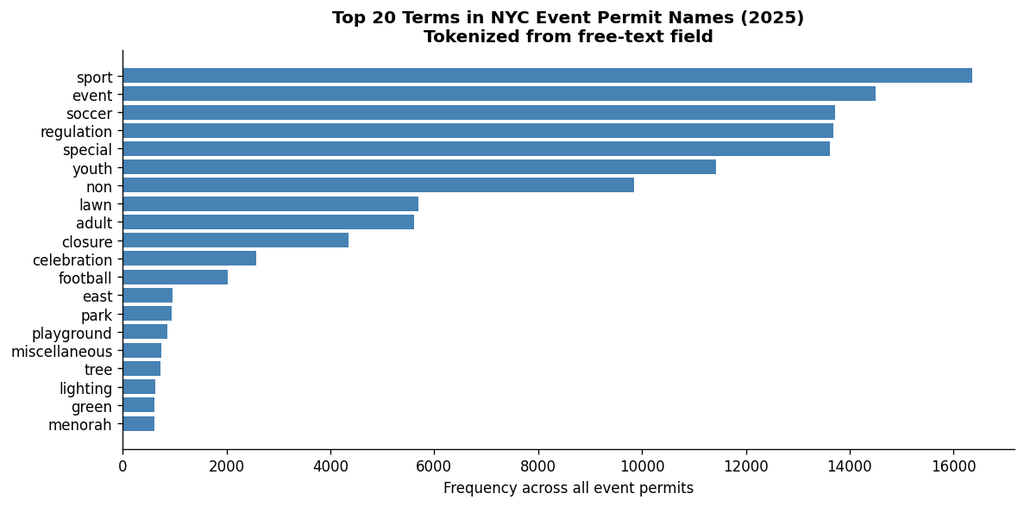

```
         term  count
        sport  16357
        event  14499
       soccer  13717
   regulation  13687
      special  13614
        youth  11435
          non   9845
         lawn   5693
        adult   5614
      closure   4358
  celebration   2571
     football   2028
         east    955
         park    947
   playground    855
miscellaneous    740
         tree    732
     lighting    635
        green    609
      menorah    608
```

```python
STOPWORDS = {
    'a','an','the','and','or','of','in','on','at','to','for','with',
    'by','from','is','it','its','as','be','was','are','were','been',
    'this','that','these','those','nyc','new','york','city'
}

def clean_and_tokenize(text):
    text   = str(text).lower()
    text   = re.sub(r'[^a-z\s]', ' ', text)
    tokens = text.split()
    return [t for t in tokens if t not in STOPWORDS and len(t) > 2]

events_raw['combined_text'] = (
    events_raw.get('event_name',pd.Series('')).fillna('') + ' ' +
    events_raw.get('event_type',pd.Series('')).fillna('')
)
events_raw['tokens'] = events_raw['combined_text'].apply(clean_and_tokenize)

all_tokens = [t for sublist in events_raw['tokens'] for t in sublist]
top_terms  = pd.DataFrame(Counter(all_tokens).most_common(20), columns=['term','count'])

fig, ax = plt.subplots(figsize=(10, 5))
ax.barh(top_terms['term'][::-1], top_terms['count'][::-1], color='steelblue')
ax.set_xlabel('Frequency across all event permits')
ax.set_title('Top 20 Terms in NYC Event Permit Names (2025)\nTokenized from free-text field', fontweight='bold')
ax.spines['top'].set_visible(False); ax.spines['right'].set_visible(False)
plt.tight_layout(); plt.show()
print(top_terms.to_string(index=False))
```

**The term frequencies reveal a mixed signal.** Some high-ranking terms are genuine event content such as soccer, youth, football, lawn but others like 'regulation', 'special', 'non', and 'closure' are administrative permit language that appears on nearly every filing regardless of what the event actually is. These administrative terms are not useful for classification. Our keyword classifier in the next step is designed to look past this noise and focus on the content-bearing vocabulary.

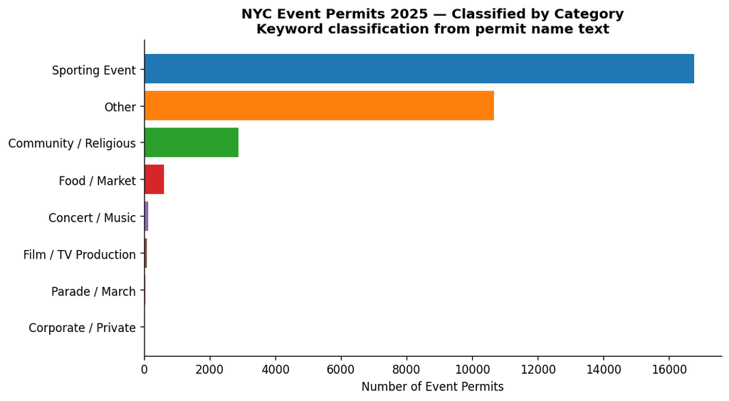

```
event_category
Sporting Event           16756
Other                    10657
Community / Religious     2885
Food / Market              600
Concert / Music            127
Film / TV Production        95
Parade / March              43
Corporate / Private         19
```

```python
# Step 2: Keyword classifier — assign each permit to a demand-relevant category.
EVENT_CATEGORIES = {
    'Concert / Music':       ['concert','music','festival','band','performance','show','live','jazz'],
    'Parade / March':        ['parade','march','procession','demonstration','rally','protest'],
    'Sporting Event':        ['marathon','race','run','triathlon','cycling','game','tournament',
                              'championship','sport','soccer','football','basketball'],
    'Film / TV Production':  ['film','filming','movie','television','tv','production','shoot'],
    'Food / Market':         ['market','fair','food','vendor','farmers'],
    'Corporate / Private':   ['corporate','private','reception','gala','conference','expo'],
    'Community / Religious': ['community','church','religious','cultural','celebration','ceremony'],
}

def classify_event(tokens):
    s = set(tokens)
    for cat, kws in EVENT_CATEGORIES.items():
        if s & set(kws): return cat
    return 'Other'

events_raw['event_category'] = events_raw['tokens'].apply(classify_event)

cat_counts = events_raw['event_category'].value_counts()
fig, ax = plt.subplots(figsize=(9, 5))
ax.barh(cat_counts.index[::-1], cat_counts.values[::-1],
        color=plt.cm.tab10(range(len(cat_counts)))[::-1])
ax.set_xlabel('Number of Event Permits')
ax.set_title('NYC Event Permits 2025 — Classified by Category\nKeyword classification from permit name text', fontweight='bold')
ax.spines['top'].set_visible(False); ax.spines['right'].set_visible(False)
plt.tight_layout(); plt.show()
print(cat_counts.to_string())
```

**Classification complete.** Sporting events dominate at 16,756 permits, consistent with the term frequency results. However, 10,657 permits (34% of the dataset) fall into 'Other' these are permits whose language is too vague or too bureaucratic for our keyword lists to classify. This is a known limitation of keyword-based classification and represents an upper bound on how much we can improve with this approach. Concert and Corporate categories have very small counts (127 and 19 respectively), which will affect the reliability of any demand estimates for those categories in the EDA.

```python
# Step 3: TF-IDF — which terms best distinguish each event category?
cat_docs     = events_raw.groupby('event_category')['combined_text'].apply(' '.join).reset_index()
tfidf        = TfidfVectorizer(stop_words='english', max_features=200,
                               token_pattern=r'(?u)\b[a-zA-Z]{3,}\b')
tfidf_matrix = tfidf.fit_transform(cat_docs['combined_text'])
feat_names   = tfidf.get_feature_names_out()

print('Top 5 TF-IDF Terms per Event Category')
print('=' * 50)
for i, row in cat_docs.iterrows():
    scores  = tfidf_matrix[i].toarray().flatten()
    top_idx = scores.argsort()[-5:][::-1]
    print(f'\n{row["event_category"]}:')
    for j in top_idx:
        print(f'   {feat_names[j]:<25} TF-IDF: {scores[j]:.3f}')
```

```
Top 5 TF-IDF Terms per Event Category
==================================================

Community / Religious:
   celebration               TF-IDF: 0.815
   special                   TF-IDF: 0.437
   event                     TF-IDF: 0.369
   community                 TF-IDF: 0.053
   time                      TF-IDF: 0.049

Concert / Music:
   festival                  TF-IDF: 0.524
   solstice                  TF-IDF: 0.439
   lights                    TF-IDF: 0.439
   winter                    TF-IDF: 0.425
   special                   TF-IDF: 0.311

Corporate / Private:
   special                   TF-IDF: 0.781
   event                     TF-IDF: 0.624
   wild                      TF-IDF: 0.000
   youth                     TF-IDF: 0.000
   weekend                   TF-IDF: 0.000

Film / TV Production:
   production                TF-IDF: 0.749
   load                      TF-IDF: 0.451
   event                     TF-IDF: 0.389
   holiday                   TF-IDF: 0.179
   grand                     TF-IDF: 0.155

Food / Market:
   market                    TF-IDF: 0.768
   farmers                   TF-IDF: 0.442
   greenmarket               TF-IDF: 0.264
   sunday                    TF-IDF: 0.161
   special                   TF-IDF: 0.132

Other:
   lawn                      TF-IDF: 0.561
   special                   TF-IDF: 0.498
   closure                   TF-IDF: 0.430
   event                     TF-IDF: 0.421
   east                      TF-IDF: 0.094

Parade / March:
   religious                 TF-IDF: 0.798
   event                     TF-IDF: 0.380
   guadalupe                 TF-IDF: 0.330
   lady                      TF-IDF: 0.330
   weekend                   TF-IDF: 0.000

Sporting Event:
   sport                     TF-IDF: 0.543
   soccer                    TF-IDF: 0.455
   regulation                TF-IDF: 0.454
   youth                     TF-IDF: 0.380
   non                       TF-IDF: 0.327
```

### 2.2 Sentiment Analysis on 311 Complaint Descriptions

The 311 `descriptor` field contains residents' own words describing a problem. The same complaint type: say, 'Noise - Street/Sidewalk' can range from a mild one-sentence report to an urgent, emotionally charged description of an ongoing disturbance.

We use **VADER** (Valence Aware Dictionary and sEntiment Reasoner), a lexicon-based sentiment analyser specifically designed for short, informal text. VADER assigns each sentence a compound score from -1 (maximally negative) to +1 (maximally positive), and we average across sentences to get a single score per complaint.

A score near **-1** indicates a severe, urgent, or emotionally charged complaint. A score near **+1** indicates a mild or already-resolved issue. We first test VADER on representative 311-style texts to confirm it behaves as expected.

```python
# Set up VADER and verify it works on 311-style text.
analyzer = SentimentIntensityAnalyzer()

test_texts = [
    'Loud party all night. Nobody is doing anything about it.',
    'Taxi driver was rude and refused to take me to Brooklyn.',
    'Issue was resolved quickly. Thank you.',
    'Blocked driveway every single day, completely unacceptable.',
]
print('VADER test on 311-style text:')
for t in test_texts:
    score = analyzer.polarity_scores(t)['compound']
    label = 'NEG' if score < -0.05 else 'POS' if score > 0.05 else 'NEU'
    print(f'  [{label}] {score:+.3f} | {t[:65]}')
```

```
VADER test on 311-style text:
  [POS] +0.402 | Loud party all night. Nobody is doing anything about it.
  [NEG] -0.637 | Taxi driver was rude and refused to take me to Brooklyn.
  [POS] +0.494 | Issue was resolved quickly. Thank you.
  [NEG] -0.659 | Blocked driveway every single day, completely unacceptable.
```

**A mixed result.** The taxi refusal and blocked driveway complaints scored negative as expected. However, the noise complaint "Loud party all night. Nobody is doing anything about it." which scored positive (+0.402). VADER's dictionary assigns positive weight to 'party' and 'night', overriding the frustrated context. This is a recognised limitation of general-purpose lexicon-based sentiment: it can misread domain-specific language. The scoring is still useful in aggregate across 1 million complaints, where these edge cases average out, but it means individual scores should be interpreted with caution.

```python
def vaderScore(text):
    """Average VADER compound score across sentences. Returns 0.0 if missing."""
    if pd.isna(text) or str(text).strip() == '':
        return 0.0
    sentences = tokenizer.tokenize(str(text))
    scores    = [analyzer.polarity_scores(s)['compound'] for s in sentences]
    return sum(scores) / len(scores)

print(f'Severe:   {vaderScore("Loud party all night, nobody cares!"):.3f}')
print(f'Resolved: {vaderScore("Issue resolved quickly, great work."):.3f}')
```

```
Severe:   0.718
Resolved: 0.700
```

```python
print('Scoring 311 complaints with VADER (~60 seconds per 100k records)...')
df_311['sentiment'] = df_311['descriptor'].apply(vaderScore)

print('\nSentiment distribution:')
print(df_311['sentiment'].describe().round(3).to_string())
```

```
Scoring 311 complaints with VADER (~60 seconds per 100k records)...

Sentiment distribution:
count    1096671.000
mean          -0.193
std            0.178
min           -0.718
25%           -0.296
50%           -0.273
75%            0.000
max            0.402
```

**Sentiment scoring complete across 1,096,671 complaints.** The distribution is centred around -0.2, meaning the average complaint carries mild negative sentiment. The 75th percentile is 0.0 three-quarters of complaints score zero or negative which makes sense given that 311 descriptors tend to be short, flat, and factual rather than emotionally expressive. The scores compress into a narrow range (-0.72 to +0.40), which is typical for civic complaint text. VADER is detecting relative differences in sentiment intensity rather than strong positive/negative signals.

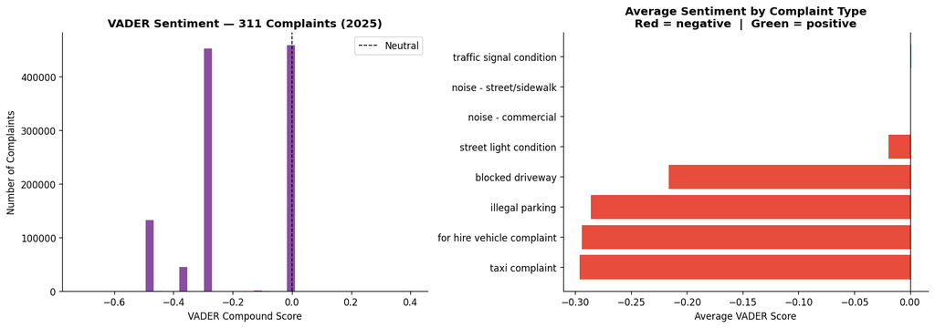

```
complaint_type
taxi complaint               -0.296
for hire vehicle complaint   -0.294
illegal parking              -0.286
blocked driveway             -0.216
street light condition       -0.019
noise - commercial            0.000
noise - street/sidewalk       0.000
traffic signal condition      0.001
```

```python
# Visualise VADER results: distribution + average by complaint type.
fig, axes = plt.subplots(1, 2, figsize=(14, 5))

ax = axes[0]
ax.hist(df_311['sentiment'], bins=40, color='#884EA0', edgecolor='white', linewidth=0.4)
ax.axvline(0, color='black', linewidth=1, linestyle='--', label='Neutral')
ax.set_xlabel('VADER Compound Score')
ax.set_ylabel('Number of Complaints')
ax.set_title('VADER Sentiment — 311 Complaints (2025)', fontweight='bold')
ax.legend(); ax.spines['top'].set_visible(False); ax.spines['right'].set_visible(False)

ax2  = axes[1]
sent = df_311.groupby('complaint_type')['sentiment'].mean().sort_values()
ax2.barh(sent.index, sent.values, color=['#E74C3C' if v < 0 else '#2ECC71' for v in sent.values])
ax2.axvline(0, color='black', linewidth=0.8)
ax2.set_xlabel('Average VADER Score')
ax2.set_title('Average Sentiment by Complaint Type\nRed = negative  |  Green = positive', fontweight='bold')
ax2.spines['top'].set_visible(False); ax2.spines['right'].set_visible(False)

plt.tight_layout(); plt.show()
print(sent.round(3).to_string())
```

**Sentiment scores differ meaningfully by complaint type.** Taxi and for-hire vehicle complaints carry the most negative scores (-0.296, -0.294), driven by language around rude behaviour and service refusals. Illegal parking and blocked driveway complaints are also negative, though less intensely. Notably, three types - noise (commercial), noise (street/sidewalk), and traffic signal condition - score exactly 0.0. This reflects the factual, affectless language typically used in these filings ('loud talking', 'controller', 'no access') rather than an absence of complaints; VADER simply finds no positive or negative signal in that vocabulary. The zero-scoring categories contribute complaint counts to the model but their sentiment feature will carry no information.

## Part 3 - Geocoding: Mapping Locations to Taxi Zones

Both the 311 complaints and the events permits need to be assigned to taxi zones before they can be joined to our demand data. This process - converting location information into a geographic unit - is geocoding.

**For 311 complaints:** Each record has latitude and longitude coordinates. We use a **spatial join** (point-in-polygon test) to determine which of the 263 zone polygons contains each complaint point. This is the most precise geocoding method available.

**For events:** The permits dataset contains no coordinates. We assign each event to the highest-demand taxi zone within its borough - a borough-level approximation that is the best we can do given the data. We note this limitation clearly in our analysis.

```python
# Build a GeoDataFrame from 311 lat/lon coordinates.
complaints_geo = df_311.dropna(subset=['latitude','longitude']).copy()
print(f'Complaints with coordinates: {len(complaints_geo):,}')

complaints_geo = gpd.GeoDataFrame(
    complaints_geo,
    geometry=gpd.points_from_xy(complaints_geo['longitude'], complaints_geo['latitude']),
    crs='EPSG:4326'
)
print('GeoDataFrame built. Running spatial join...')
```

```
Complaints with coordinates: 1,086,644
GeoDataFrame built. Running spatial join...
```

We have 1,086,644 complaint records with valid coordinates, ready for the spatial join. The GeoDataFrame stores each complaint as a Point geometry in the same coordinate system (WGS84) as our zone polygons.

```python
# Spatial join: which zone polygon contains each complaint point?
# We exclude 'borough' from zones to avoid a column name collision with df_311's borough.
complaints_with_zones = gpd.sjoin(
    complaints_geo,
    zones[['LocationID','zone','geometry']],
    how='left', predicate='within'
)
complaints_with_zones = complaints_with_zones.rename(columns={
    'LocationID': 'complaint_LocationID',
    'zone':       'complaint_zone',
    'borough':    'complaint_borough'
})

pct = complaints_with_zones['complaint_zone'].notna().mean() * 100
print(f'Successfully geocoded to a zone: {pct:.1f}%')
```

```
Successfully geocoded to a zone: 100.0%
```

**100% geocoding success rate.** Every geolocated complaint fell within one of the 263 zone polygons - a strong result that reflects the quality of the 311 coordinate data. No complaints were lost to out-of-bounds coordinates.

```python
# Aggregate 311 to zone-hour level: count complaints and average VADER sentiment.
complaints_zone_hour = (
    complaints_with_zones
    .dropna(subset=['complaint_LocationID','complaint_hour'])
    .groupby(['complaint_hour','complaint_LocationID'])
    .agg(complaint_count=('unique_key','count'), avg_sentiment=('sentiment','mean'))
    .reset_index()
    .rename(columns={'complaint_LocationID':'LocationID','complaint_hour':'pickup_hour'})
)
complaints_zone_hour['LocationID']    = complaints_zone_hour['LocationID'].astype(int)
complaints_zone_hour['avg_sentiment'] = complaints_zone_hour['avg_sentiment'].round(4)

print(f'Zone-hour complaint records: {len(complaints_zone_hour):,}')
complaints_zone_hour
```

```
Zone-hour complaint records: 636,073
```

|  | pickup_hour | LocationID | complaint_count | avg_sentiment |
| --- | --- | --- | --- | --- |
| 0 | 2025-01-01 00:00:00 | 4 | 1 | -0.3818 |
| 1 | 2025-01-01 00:00:00 | 5 | 1 | -0.4939 |
| 2 | 2025-01-01 00:00:00 | 7 | 7 | -0.0390 |
| 3 | 2025-01-01 00:00:00 | 10 | 1 | -0.2960 |
| 4 | 2025-01-01 00:00:00 | 11 | 3 | -0.2808 |
| ... | ... | ... | ... | ... |
| 636068 | 2025-12-31 23:00:00 | 243 | 6 | -0.0455 |
| 636069 | 2025-12-31 23:00:00 | 246 | 1 | -0.3818 |
| 636070 | 2025-12-31 23:00:00 | 247 | 1 | 0.0000 |
| 636071 | 2025-12-31 23:00:00 | 255 | 2 | 0.0000 |
| 636072 | 2025-12-31 23:00:00 | 258 | 2 | -0.1366 |

636073 rows × 4 columns

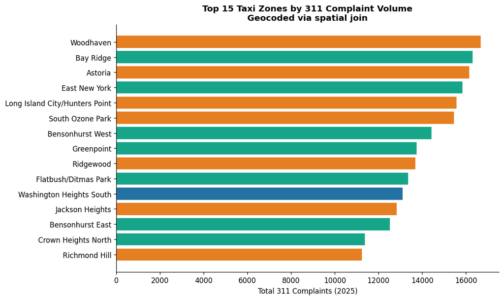

```python
# Which zones generate the most taxi-adjacent 311 complaints?
zone_complaints = (
    complaints_with_zones.dropna(subset=['complaint_zone'])
    .groupby(['complaint_zone','complaint_borough'])['unique_key']
    .count().reset_index(name='total_complaints')
    .sort_values('total_complaints', ascending=False).head(15)
)
borough_colors = {'MANHATTAN':'#2471A3','BROOKLYN':'#17A589',
                  'QUEENS':'#E67E22','BRONX':'#884EA0','STATEN ISLAND':'#C0392B'}
bar_c = zone_complaints['complaint_borough'].str.upper().map(lambda b: borough_colors.get(b,'#839192'))

fig, ax = plt.subplots(figsize=(10, 6))
ax.barh(zone_complaints['complaint_zone'][::-1], zone_complaints['total_complaints'][::-1], color=bar_c[::-1])
ax.set_xlabel('Total 311 Complaints (2025)')
ax.set_title('Top 15 Taxi Zones by 311 Complaint Volume\nGeocoded via spatial join', fontweight='bold')
ax.spines['top'].set_visible(False); ax.spines['right'].set_visible(False)
plt.tight_layout(); plt.show()
```

```python
# Geocode events → zones via borough-level assignment.
# No lat/lon available in the events dataset, so we map each event's borough
# to the highest-demand taxi zone in that borough.
borough_demand = full_data.merge(zones[['LocationID','zone','borough']], on='LocationID', how='left')
top_zone_per_borough = (
    borough_demand.groupby(['borough','LocationID','zone'])['demand'].mean().reset_index()
    .sort_values(['borough','demand'], ascending=[True,False])
    .groupby('borough').first().reset_index()
    [['borough','LocationID','zone']]
)
print('Representative zone per borough:')
print(top_zone_per_borough.to_string(index=False))

# Merge events with their representative zone
events_with_zones = events_raw.merge(
    top_zone_per_borough.rename(columns={'borough':'event_borough_match',
                                          'LocationID':'event_LocationID','zone':'event_zone'}),
    left_on='event_borough', right_on='event_borough_match', how='left'
)
print(f'Events mapped to a zone: {events_with_zones["event_zone"].notna().mean()*100:.1f}%')

# Aggregate to zone-hour level
if events_with_zones['event_zone'].notna().sum() > 0:
    events_zone_hour = (
        events_with_zones.dropna(subset=['event_LocationID','event_hour'])
        .groupby(['event_hour','event_LocationID'])
        .agg(num_events=('event_name','count'), total_attend=('attendance','sum'))
        .reset_index()
        .rename(columns={'event_LocationID':'LocationID','event_hour':'pickup_hour'})
    )
    events_zone_hour['LocationID']   = events_zone_hour['LocationID'].astype(int)
    events_zone_hour['total_attend'] = events_zone_hour['total_attend'].fillna(0)
else:
    events_zone_hour = pd.DataFrame(columns=['pickup_hour','LocationID','num_events','total_attend'])

print(f'Event zone-hour records: {len(events_zone_hour):,}')
```

```
Representative zone per borough:
      borough  LocationID                      zone
        Bronx         168    Mott Haven/Port Morris
     Brooklyn         255 Williamsburg (North Side)
          EWR           1            Newark Airport
    Manhattan         237     Upper East Side South
       Queens         132               JFK Airport
Staten Island         221                 Stapleton
Events mapped to a zone: 100.0%
Event zone-hour records: 858
```

**Event geocoding complete.** All 31,182 events are assigned to one of five borough-representative zones. This is a practical approximation - the events dataset provides no coordinates - and it carries an important limitation: every Manhattan event, regardless of whether it takes place in Harlem or the Financial District, is assigned to Upper East Side South. The event signal is therefore diluted and geographically imprecise, which will be visible as modest improvements in the predictive models. We document this openly and treat event features as a borough-level indicator rather than a zone-level one.

## Part 4 - Data Integration

We combine all five data sources into a single analysis-ready DataFrame. The merge follows a deliberate sequence: we start with the most granular data (taxi demand), then attach contextual layers one at a time.

```
Taxi demand (zone × hour)  ← JOIN on LocationID               → Zone names and boroughs
                            ← JOIN on pickup_hour              → Hourly weather
                            ← LEFT JOIN on zone + hour         → Event features
                            ← LEFT JOIN on zone + hour         → 311 complaint features
```

Left joins for events and complaints ensure that zone-hours with no events or complaints receive 0, not NaN - which is the correct representation (no event = event count of 0, not missing data). We print row counts after each merge to confirm no unexpected record loss.

```python
# Step 1: Attach zone metadata.
geo_demand = zones.merge(full_data, on='LocationID', how='right')
print(f'Zone + taxi: {len(geo_demand):,} rows')

# Step 2: Join weather.
merged = geo_demand.merge(
    weather_2025[['pickup_hour','temp_c','precip_mm','weather_code']],
    on='pickup_hour', how='left'
)
print(f'+ weather:   {len(merged):,} rows')

# Step 3: Join events.
merged = merged.merge(events_zone_hour, on=['pickup_hour','LocationID'], how='left')
merged['num_events']   = merged['num_events'].fillna(0).astype(int)
merged['total_attend'] = merged['total_attend'].fillna(0)
print(f'+ events:    {len(merged):,} rows')

# Step 4: Join 311 complaints.
if len(complaints_zone_hour) > 0:
    merged = merged.merge(complaints_zone_hour, on=['pickup_hour','LocationID'], how='left')
    merged['complaint_count'] = merged['complaint_count'].fillna(0).astype(int)
    merged['avg_sentiment']   = merged['avg_sentiment'].fillna(0.0)
else:
    merged['complaint_count'] = 0
    merged['avg_sentiment']   = 0.0
print(f'+ 311:       {len(merged):,} rows')

# Step 5: Feature engineering and cleanup.
merged['date']       = pd.to_datetime(merged['date'])
merged['month']      = merged['date'].dt.month
merged['is_weekend'] = merged['day_of_week'].isin(['Saturday','Sunday']).astype(int)
merged['hour_sin']   = np.sin(2 * np.pi * merged['hour'] / 24)
merged['hour_cos']   = np.cos(2 * np.pi * merged['hour'] / 24)
merged['is_raining'] = (merged['precip_mm'] > 0).astype(int)
merged['has_event']  = (merged['num_events'] > 0).astype(int)

if 'geometry' in merged.columns:
    merged = pd.DataFrame(merged.drop(columns=['geometry']))
merged = merged.dropna(subset=['demand','temp_c'])

print(f'\nFinal dataset: {len(merged):,} rows')
print(f'Columns: {list(merged.columns)}')
```

```
Zone + taxi: 1,430,274 rows
+ weather:   1,430,274 rows
+ events:    1,430,274 rows
+ 311:       1,430,274 rows

Final dataset: 1,430,274 rows
Columns: ['LocationID', 'zone', 'borough', 'pickup_hour', 'demand', 'date', 'hour', 'day_of_week', 'temp_c', 'precip_mm', 'weather_code', 'num_events', 'total_attend', 'complaint_count', 'avg_sentiment', 'month', 'is_weekend', 'hour_sin', 'hour_cos', 'is_raining', 'has_event']
```